# Sector growth

Time series forecasting

# Loading and preparing data

The used configuration file, config.yml:

```
## # Processing switches
## process_companies: FALSE
## process_aggregate: FALSE
##
## # Analysis variables
## date_start: "1997-01-01"
## date_end: "2017-10-01"
## qty_companies_in_rolledup: 50000
## code_nace: "47"
## months_forecast: 12
##
## # End of YAML
```

The company data and SBI code hierarchy is loaded:

```r
# Import & transform company data ----
tbl_companies <- prep_companies(config$process_companies,
                                var_date_from,
                                var_date_to)
# Import branche hierarchy data
tbl_nace <- read.csv2(paste0(dir_input, "/branche_hierarchy.csv"),
                      stringsAsFactors = FALSE)
```

## Rolling up the NACE hierarchy

The number of companies per nace code in the company file can be small, making it unsuitable for time series forecasting. For this reason the number of companies are aggregated though the NACE hierarchy, by propagating codes with the small number of companies to higher hierarchy codes.

To get this mechanism working the first need to add the number of companies for each of the NACE codes to the complete NACE hierarchy.

```r
# Add number of companies to the NACE hierarchy, so all
tbl_nace_qty <- tbl_nace %>%
  left_join(tbl_companies, by = c("code" = "sbi_full")) %>%
  group_by(code, code_parent, layer_no) %>%
  summarise(qty = n_distinct(id_giant, na.rm = TRUE)) %>%
  ungroup()
```

This is how the NACE hierarchy looks now; many sectors with a small number of companies:

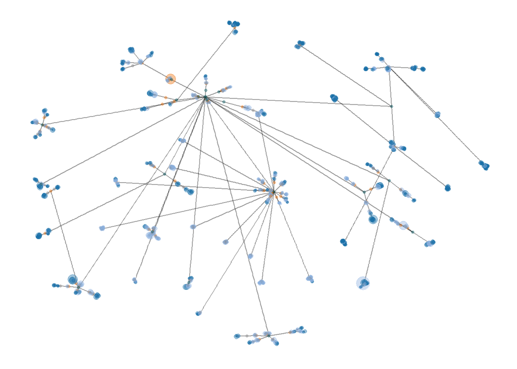

Now the actual roll up is done after which the ‘translation table’ is joined to the table with companies table:

```r
lst_nace_recoding <- roll_up_nace_tree(tbl_nace_qty, config$qty_companies_in_rolledup)

tbl_companies %<>%
  left_join(lst_nace_recoding$tbl_dictionary, by = c("sbi_full" = "code"))
```

That results in the hierarchy below, containing far less sectors with a higher number of companies, making forecasting success more likely:

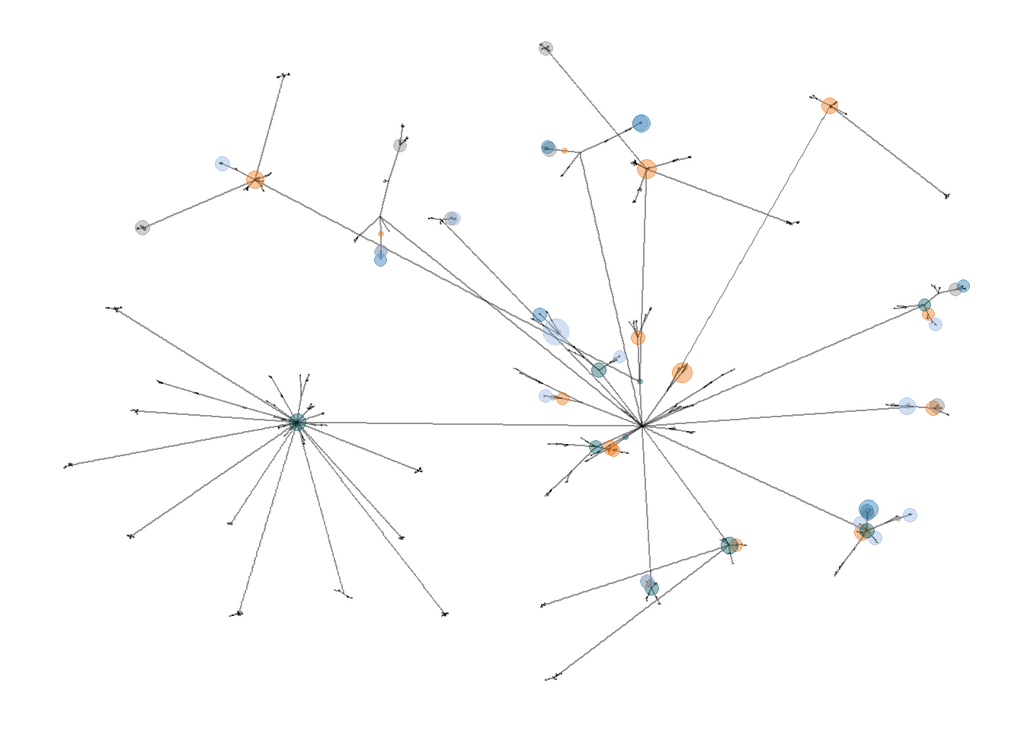

## Spreading companies through time

A time series is a series of data points indexed in time order. In this step the companies are put in each month within a time frame, specified by the config file, according to their date of establishment and discontinuation.

Depending on the processing configuration, the data is processed *or* pre-processed is loaded; after which NACE descriptions are added.

```r
# Depending on the processing configuration the data is processed
if(config$process_aggregate){
  tbl_companies_aggr <- aggregate_companies(tbl_companies, lst_nace_recoding$tbl_dictionary)
  saveRDS(tbl_companies_aggr, file = paste0(dir_input, "/companies_aggr.RDS"))
} else {
  # or pre-processed is loaded
  tbl_companies_aggr <- read_rds(paste0(dir_input, "/companies_aggr.RDS"))
}

tbl_companies_aggr %<>%
  rename(code = code_new) %>%
  left_join(tbl_nace, by = "code")
```

# Initial exploration

## Development of the number of companies per sector

Now we can take a quick look at the development number of companies in each sector:

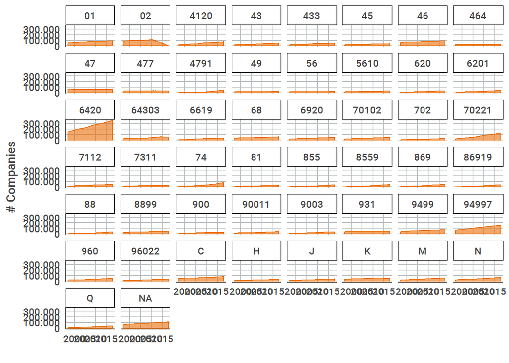

```r
ggplot(tbl_companies_aggr, aes(x = month, y = qty_companies)) +
  geom_area(col = col_graydon[2], fill = col_graydon[2], alpha = .6) +
  facet_wrap(~ code) +
  scale_y_continuous(labels = format_number) +
  labs(x = "", y = "# Companies") +
  theme_graydon("grid")
```

The sector with NACE code 47 looks like an interesting candidate, because it has no obvious trend, which would make it more challenging to forecast.

## Development of retail sector

When zooming in on this NACE code

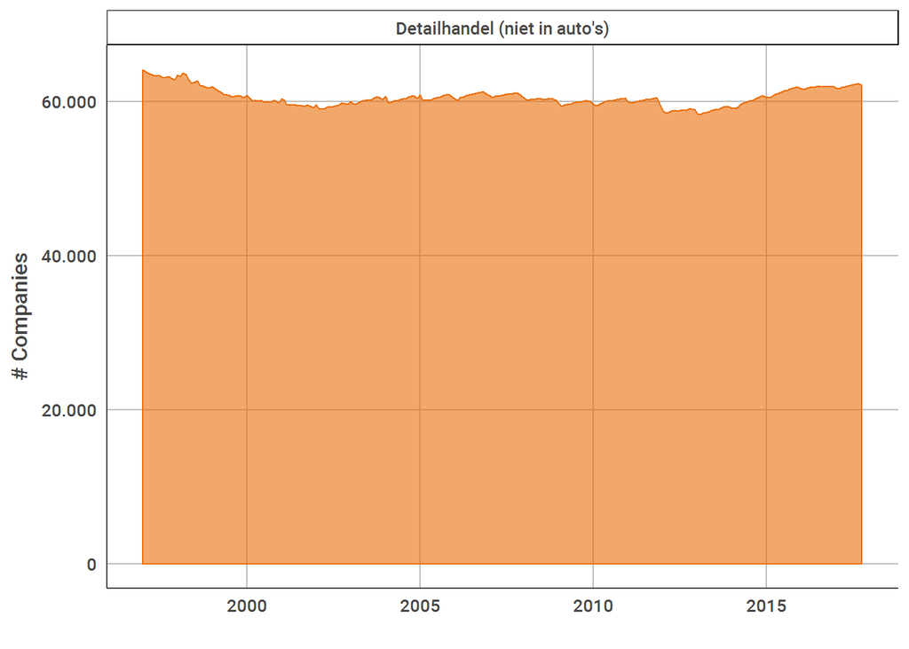

# Creating and cleaning the time series

```r
# Timeseries exploration ----
library(forecast)
library(ggfortify)

# Get selected nace code
tbl_companies_code <- tbl_companies_aggr %>% filter(code == config$code_nace)
var_sector <- (tbl_nace %>% filter(code == config$code_nace))$description

# Create time series
ts_companies <- ts(tbl_companies_code$qty_companies,
                   frequency = 12,
                   start = c(year(var_date_from), month(var_date_from)) )

# Clean time series
ts_companies_clean <- tsclean(ts_companies)
```

### Compare original and cleaned time series

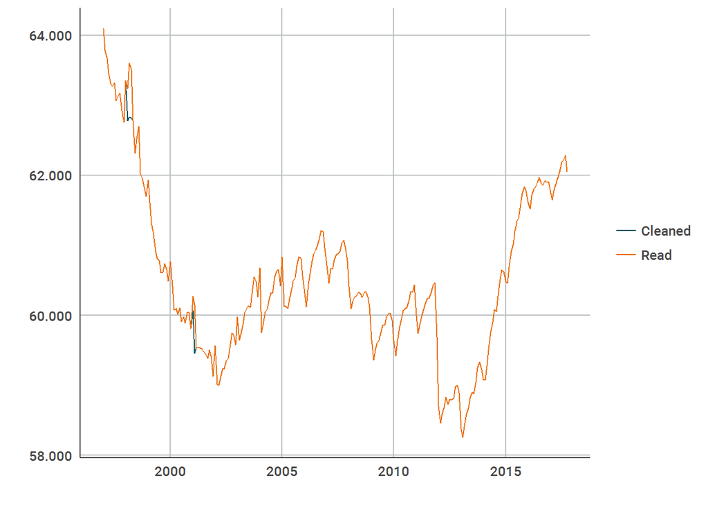

```r
# Plot imported vs. cleaned time series
plot_time_series(list(ts_companies, ts_companies_clean),
                 c("Read", "Cleaned"))
```

## Forecasting

### Create a training set

```r
ts_companies_train = subset(ts_companies_clean, end = length(ts_companies_clean) - months_forecast)
```

### Create forecast models

```r
fit_mean <- meanf(ts_companies_train, h = months_forecast)    # Mean forecasting (mean of all observations)
fit_naive <- naive(ts_companies_train, h = months_forecast)   # Naive
fit_snaive <- snaive(ts_companies_train, h = months_forecast) # Naive seasonal
fit_ses <- ses(ts_companies_train, h = months_forecast)       # Simple exponential smoothing
fit_holt <- holt(ts_companies_train, h = months_forecast)     # Holt’s linear trend
fit_hw_m <- hw(ts_companies_train, h = months_forecast, seasonal = "multiplicative")  # Holt-Winters multiplicative
fit_hw_a <- hw(ts_companies_train, h = months_forecast, seasonal = "additive")        # Holt-Winters additive
model_ets <- ets(ts_companies_train)                # Errors, Trend, and Seasonality (ETS)
fit_ets <- forecast(model_ets, h = months_forecast)
model_auto.arima <- auto.arima(ts_companies_train)  # ARIMA (automatic)
fit_auto.arima <- forecast(model_auto.arima, h = months_forecast)
```

### Evaluate forecast models by MASE

```r
lst_fitted <- list(fit_mean, fit_naive, fit_snaive, fit_holt, fit_hw_m, fit_hw_a,
                   fit_ets, fit_ses, fit_auto.arima)
lst_evaluations <- lapply(lst_fitted, evaluate_forecast, ts_companies_clean)
```

### All forecast model results

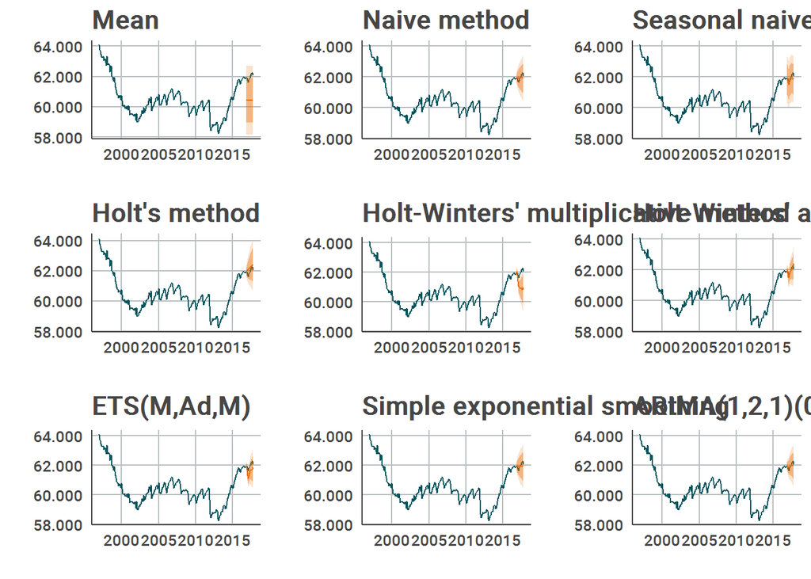

```r
lst_forecast_plots <- sapply(lst_evaluations, "[", 1)
do.call("grid.arrange", c(lst_forecast_plots, ncol=3))
```

### Compare models based on MASE evaluation

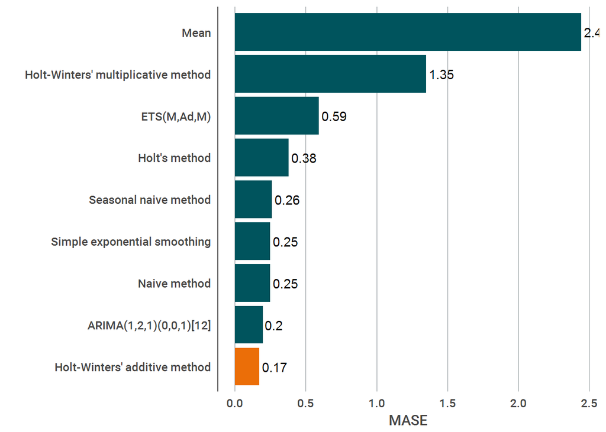

```r
# Review MASE
tbl_forecast_mase <- do.call("rbind", sapply(lst_evaluations, "[", 2))
tbl_forecast_mase %>%
  mutate(is_best = MASE == min(MASE)) %>%
  ggplot(aes(x = reorder(method, MASE), y = MASE)) +
  geom_col(aes(fill = is_best)) +
  geom_text(aes(label = round(MASE, 2)),
            hjust = -.1) +
  scale_fill_graydon() +
  coord_flip() +
  labs(x = "") +
  guides(fill = FALSE) +
  theme_graydon("vertical")
```

### The best performing forecast method

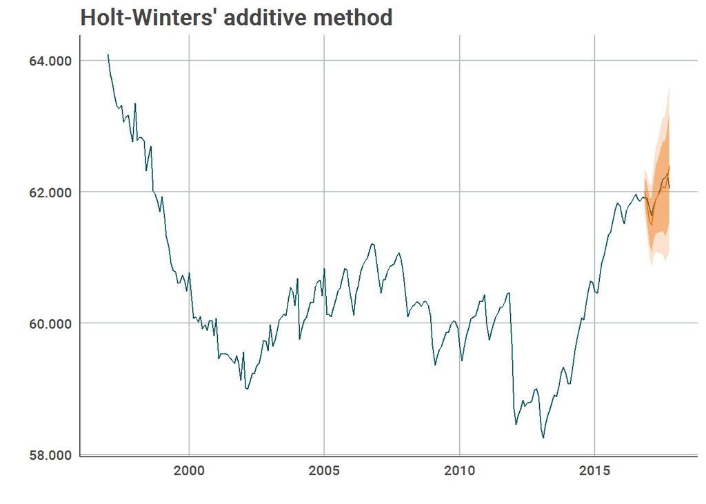

```r
no_best <- (tbl_forecast_mase %>%
              mutate(row_no = row_number()) %>%
              mutate(is_best = MASE == min(MASE)) %>%
              filter(is_best))$row_no
lst_forecast_plots[no_best]
```

### Apply best forecasting method

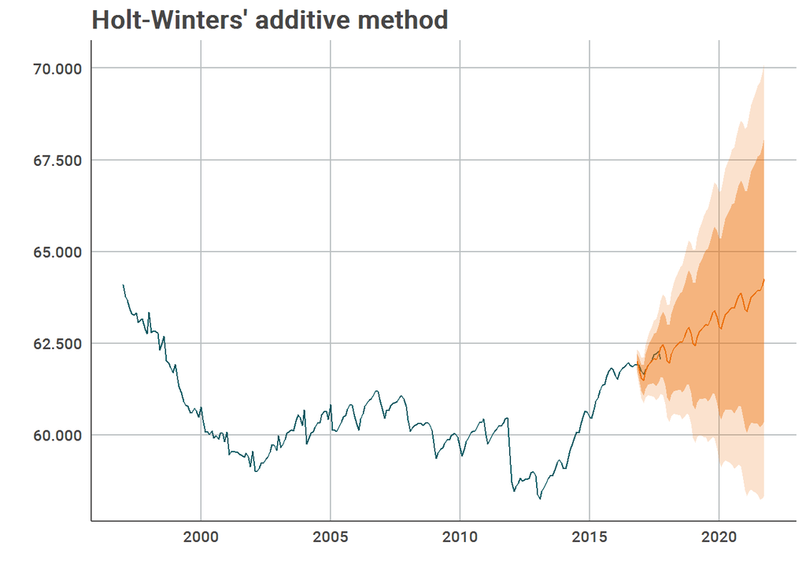

```r
fit_hw_a <- hw(ts_companies_train, h = 60, seasonal = "additive")
result_fit <- evaluate_forecast(fit_hw_a, ts_companies_clean)
result_fit$p_forecast
```